# LR1

Riyaz Panjwani

September 27, 2016

## Approach to the problem

The problem seems to be quite intuitive, using a regression algorithm is what comes to the mind. You could use Random Forest, Decision tree or any linear model. The data set is not very big with very less number of features. Before arriving to the conclusion of using the specified model and the obtaining the parameters for deciding the outcome a comprehensive study of data was performed using plotting and various visualization techniques (featurePlot, ggplot, plot etc.)

## Getting the data

In order to reproduce the same results, you need a certain set of packages, as well as setting a pseudo random seed equal to the one I used. Note:To install, for instance, the caret package in R, run this command: install.packages(“caret”)

The following Libraries were used for this project, which you should install - if not done yet - and load on your working environment

```r
library(lattice)
library(ggplot2)
library(caret)
library(car)
library(randomForest)
set.seed(1234)
```

```r
train <- read.csv("G:\\training_set_q1.csv")
test <- read.csv("G:\\test_set_q1_upload.csv")

dim(train)
```

```
## [1] 549  33
```

```r
dim(test)
```

```
## [1] 100  30
```

```r
names(train)
```

```
##  [1] "school"     "sex"        "age"        "address"    "famsize"
##  [6] "Pstatus"    "Medu"       "Fedu"       "Mjob"       "Fjob"
## [11] "reason"     "guardian"   "traveltime" "studytime"  "failures"
## [16] "schoolsup"  "famsup"     "paid"       "activities" "nursery"
## [21] "higher"     "internet"   "romantic"   "famrel"     "freetime"
## [26] "goout"      "Dalc"       "Walc"       "health"     "absences"
## [31] "G1"         "G2"         "G3"
```

## Clean Data

The data appears to be clean with no **NA** values.The values are integers are the desired output is a value in the continuous range (0,20).

```r
trainG1 <- subset(train,select = -c(G2,G3))
trainG2 <- subset(train,select = -c(G1,G3))
trainG3 <- subset(train,select = -c(G1,G2))
```

## Data Slicing

Slice the data for prediction and avoiding overfitting.

```r
inTrain <- createDataPartition(y = trainG1$G1,p=0.75,list = FALSE)
training <- trainG1[inTrain,]
testing <- trainG1[-inTrain,]
```

## Modal Fitting

```r
#Modal Fit
#modFit <- train(G1~.,methods = "gbm",data = training,verbose = FALSE)
modFitL1 <- train(G1~.,methods = "lasso",data = training,verbose = FALSE)
print(modFitL1)
```

```
## Random Forest
##
## 413 samples
##  30 predictor
##
## No pre-processing
## Resampling: Bootstrapped (25 reps)
## Summary of sample sizes: 413, 413, 413, 413, 413, 413, ...
## Resampling results across tuning parameters:
##
##   mtry  RMSE      Rsquared
##    2    2.427496  0.2906893
##   20    2.363118  0.2858366
##   39    2.394362  0.2714920
##
## RMSE was used to select the optimal model using  the smallest value.
## The final value used for the model was mtry = 20.
```

## Plots

Plot the prediction over the actual values.

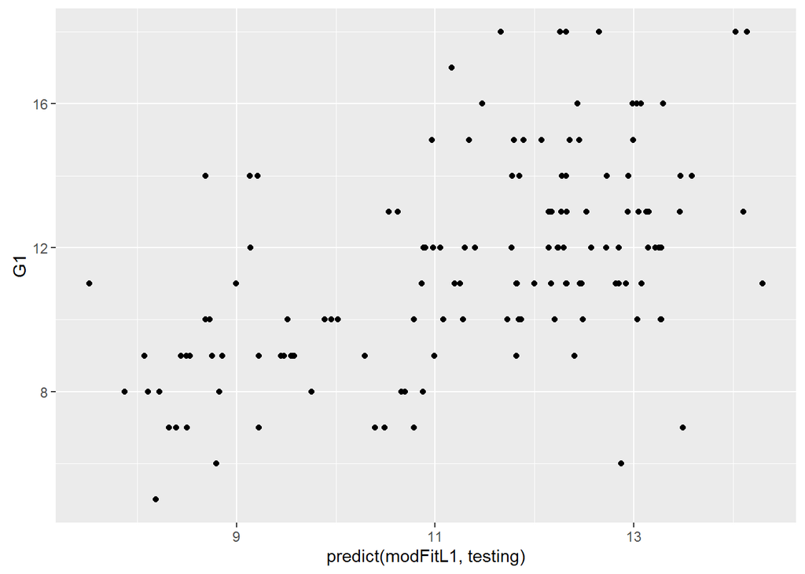

```r
#Plots
qplot(predict(modFitL1,testing),G1,data = testing)
```

## Prediction over testing set

```r
predL1 <- predict(modFitL1,testing)
rmse <- mean((testing$G1-predL1)^2)
print(rmse)
```

```
## [1] 5.875904
```

## Model fitting for G2

Using the same procedure for predicting the value of G2.

```r
inTrain <- createDataPartition(y = trainG2$G2,p=0.75,list = FALSE)
training <- trainG2[inTrain,]
testing <- trainG2[-inTrain,]

#modFitGBM2 <- train(G2~.,methods = "gbm",data = training,verbose = FALSE)
modFitL2 <- train(G2~.,methods = "lasso",data = training,verbose = FALSE)
print(modFitL2)
```

```
## Random Forest
##
## 414 samples
##  30 predictor
##
## No pre-processing
## Resampling: Bootstrapped (25 reps)
## Summary of sample sizes: 414, 414, 414, 414, 414, 414, ...
## Resampling results across tuning parameters:
##
##   mtry  RMSE      Rsquared
##    2    2.704337  0.2651488
##   20    2.649484  0.2665128
##   39    2.695073  0.2541932
##
## RMSE was used to select the optimal model using  the smallest value.
## The final value used for the model was mtry = 20.
```

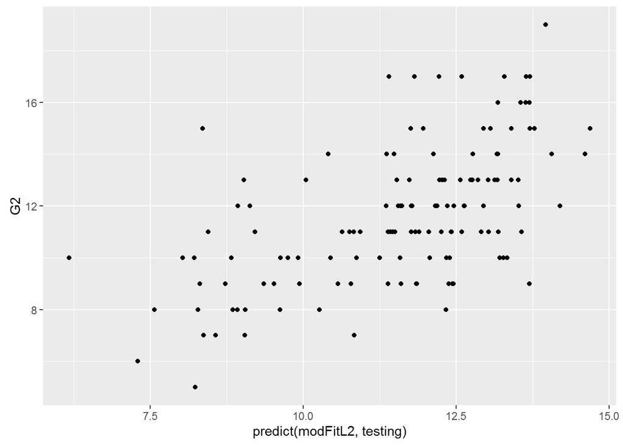

```r
qplot(predict(modFitL2,testing),G2,data = testing)
```

```r
#pred <- predict(modFit,testing)
predL2 <- predict(modFitL2,testing)
rmse <- mean((testing$G2-predL2)^2)
print(rmse)
```

```
## [1] 4.791767
```

## Modal fitting for G3

Using the same procedure for predicting the value of G3.

```r
inTrain <- createDataPartition(y = trainG3$G3,p=0.75,list = FALSE)
training <- trainG3[inTrain,]
testing <- trainG3[-inTrain,]

modFitL3 <- train(G3~.,methods = "lasso",data = training,verbose = FALSE)
print(modFitL3)
```

```
## Random Forest
##
## 414 samples
##  30 predictor
##
## No pre-processing
## Resampling: Bootstrapped (25 reps)
## Summary of sample sizes: 414, 414, 414, 414, 414, 414, ...
## Resampling results across tuning parameters:
##
##   mtry  RMSE      Rsquared
##    2    2.861955  0.2882963
##   20    2.811330  0.2769125
##   39    2.901113  0.2500871
##
## RMSE was used to select the optimal model using  the smallest value.
## The final value used for the model was mtry = 20.
```

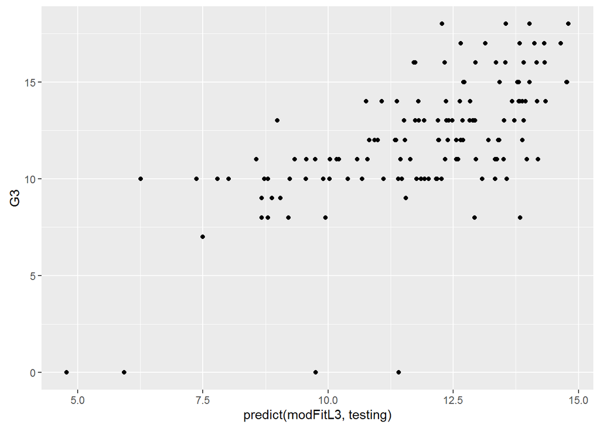

```r
qplot(predict(modFitL3,testing),G3,data = testing)
```

```r
#pred      <- predict(modFit,testing)
predL3 <- predict(modFitL3,testing)
rmse <- mean((testing$G3-predL3)^2)
print(rmse)
```

```
## [1] 6.228774
```

## Final Submission

```r
##Predicting the test set

test.org <- read.csv("G:\\test_set_q1_upload.csv")
pred <- predict(modFitL1,test.org)
test$G1 <- pred
pred <- predict(modFitL2,test.org)
test$G2 <- pred
pred <- predict(modFitL3,test.org)
test$G3 <- pred
dim(test)
```

```
## [1] 100  33
```

```r
View(test)
```